# Easy Way #1

Charting graduation and retention rates over time for PSU and some peer institutions.

```r
library(tidyverse)
library(ipeds)
library(reshape2)
```

```r
library(ggplot2)
library(ggthemes)
library(gridExtra)
library(scales)
dir <- "C:\\Users\\mjs26\\Documents\\R\\R-3.6.1\\library\\ipeds\\data\\downloaded"
```

These are the colleges we’re interested in, selected by IPEDS ID. This happens to be Portland State University and some of our traditional peer list.

```r
the_colleges <- c(232186, 151111, 122409, 145600, 220862, 228769, 206084, 240453, 172699, 209807 )
```

We pull the most recent IC collection, to get their names and other details:

```r
# Load up the IC

directory <- ipeds_survey(table = 'HD', year = 2018, dir=dir)
names(directory) <- tolower(names(directory))

# Create a unit ID <-> Institution name crosswalk.

getinstnm <- directory$instnm
names(getinstnm) <- directory$unitid
```

# Graduation

Now we get 150% graduation rates. First, we define a function that opens an IPEDS GR for the supplied year, and returns a dataframe containing the adjusted cohort, the number of completers, and the rate.

```r
grad_rate_get <- function(year) {
  gradrates <- (ipeds_survey(table='GR',year=year, dir=dir))
  names(gradrates) <- tolower(names(gradrates))
  theRates <- dcast(gradrates, unitid ~ grtype, value.var = 'grtotlt')
  names(theRates) <- c('unitid','adjusted_cohort','completers')
  theRates$rate <- theRates$completers/theRates$adjusted_cohort
  theRates$year <- year
  return(theRates[, c('unitid','year','adjusted_cohort','completers','rate')])
}
```

Then we make a list of the years we’re interested in.

```r
years <- (2012:2018)
years
```

```
## [1] 2012 2013 2014 2015 2016 2017 2018
```

We run the function for each of those years, and then we combine them into a single (very tall) dataframe. We still have all 7,000+ institutions in the dataset at this point.

```r
for (i in seq_along(years)) {
  if (i==1) {grad_rate <- grad_rate_get(years[i])}
  else {grad_rate <- rbind(grad_rate, grad_rate_get(years[i]))}
}
```

# Retention

This works just like the graduation rates, and we’ll use the same list of years. Note that we’re pulling in two different components of the Fall Enrollment collection; one has the rate, and the other has the total enrollment.

```r
retention_get <- function(year) {
  efd <-  ipeds_survey(table='EFD', year=year, dir=dir)
  names(efd) <- tolower(names(efd))
  efd$retention_rate <- as.numeric(efd$ret.pcf)
  efd$year <- year
  return(efd[,c('unitid','year','retention_rate')])
}

fall_enrollment_get <- function(year) {
  efa <-ipeds_survey(table='EFA', year=year, dir=dir)
  names(efa) <- tolower(names(efa))
  efa <- efa %>%
    filter(efalevel==2) %>% # This is the total undergraduate enrollment row
    rename(total_enrollment = eftotlt )
  efa$year <- year
  return(efa[,c('unitid','year','total_enrollment')])
}


for (i in seq_along(years)) {
  if (i==1) {fall_enrollment <- fall_enrollment_get(years[i])}
  else {fall_enrollment <- rbind(fall_enrollment, fall_enrollment_get(years[i]))}
}


for (i in seq_along(years)) {
  if (i==1) {retention <- retention_get(years[i])}
  else {retention <- rbind(retention, retention_get(years[i]))}
}
```

# Outputting

I’m just going to use ggplot to do some simple (and mostly bad) charts for illustrative purposes. You might want to build on these and make them better, or export the two datasets from R into your favorite data-viz tool.

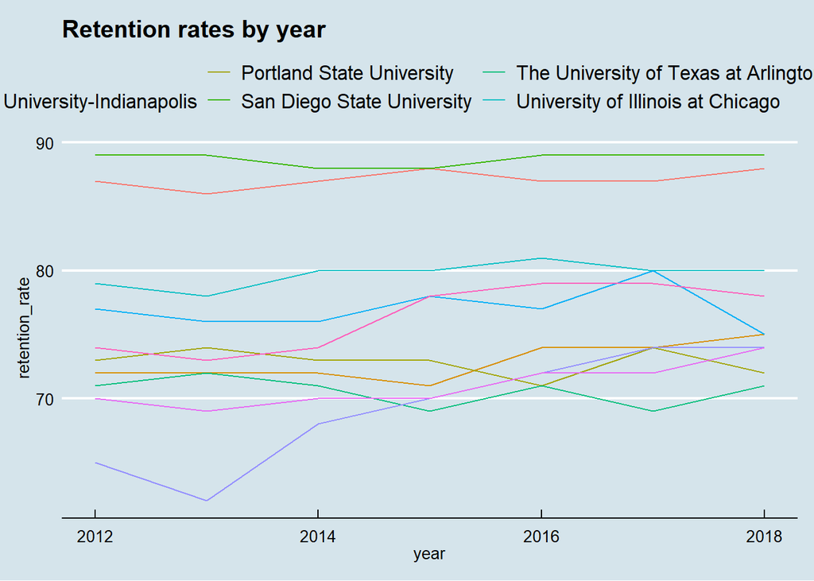

```r
retention %>%
  filter(unitid %in% the_colleges) %>%
  ggplot(aes(year, retention_rate)) +
  theme_economist() +
  geom_line(aes(colour=factor(getinstnm[as.character(unitid)]) )) +
  ggtitle('Retention rates by year')
```

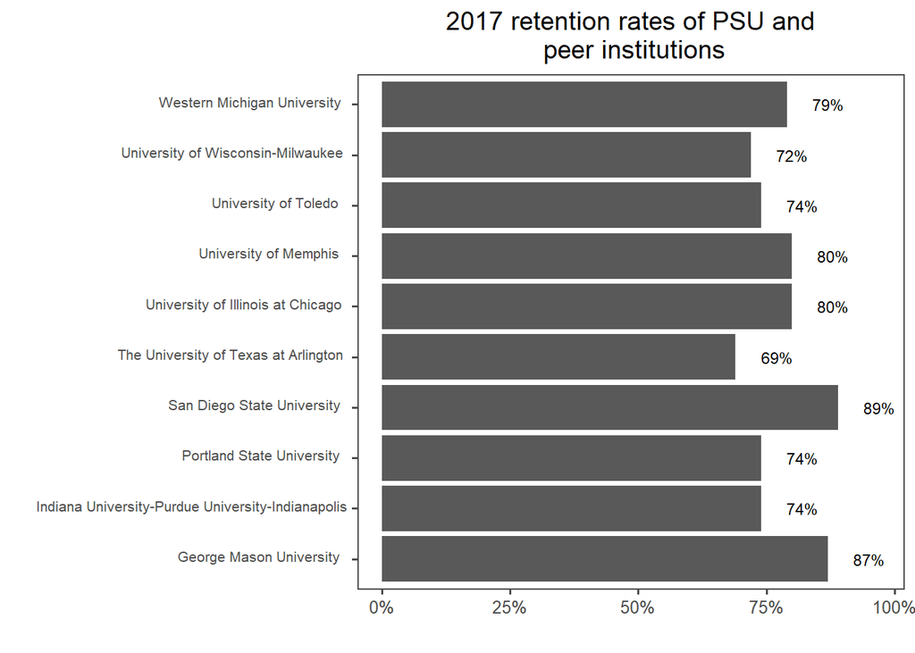

```r
 retention %>%
  mutate(retention_rate = retention_rate/100) %>%
  filter(unitid %in% the_colleges) %>%
  filter(year == 2017)%>%
  arrange((getinstnm[as.character(unitid)])) %>%
  ggplot(aes((getinstnm[as.character(unitid)]), retention_rate)) +
  geom_bar(stat="identity") +
    theme_few() +
  theme(legend.position="none") +
  scale_y_continuous(labels = scales::percent) +
  geom_text(aes(label=paste0(round(retention_rate*100,1),"%"), y=retention_rate+0.08), size=3) +
  coord_flip() +
  ylab('') +
  xlab('') +
  theme(axis.text.y=element_text(size=8, hjust=0.95,vjust=0.2)) +
  ggtitle('2017 retention rates of PSU and\n peer institutions') +
  theme(plot.title = element_text(hjust = 0.5))
```

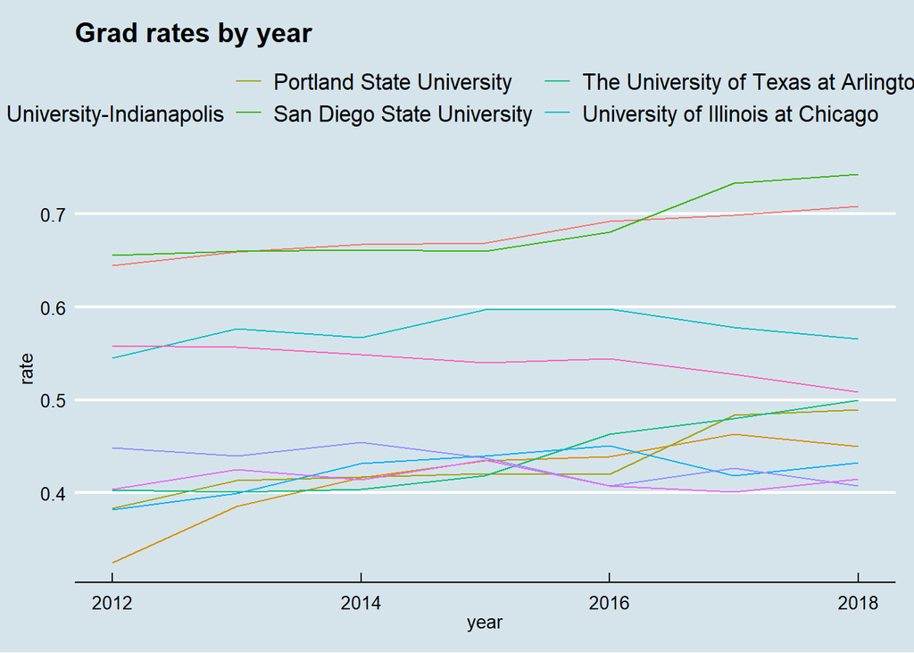

```r
grad_rate %>%
  filter(unitid %in% the_colleges) %>%
  ggplot(aes(year, rate)) +
  theme_economist() +
  geom_line(aes(colour=factor(getinstnm[as.character(unitid)]) )) +
  ggtitle('Grad rates by year')
```

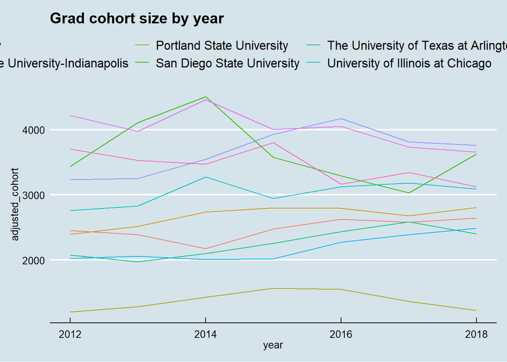

```r
grad_rate %>%
  filter(unitid %in% the_colleges) %>%
  ggplot(aes(year, adjusted_cohort)) +
  theme_economist() +
  geom_line(aes(colour=factor(getinstnm[as.character(unitid)]) )) +
  ggtitle('Grad cohort size by year')
```

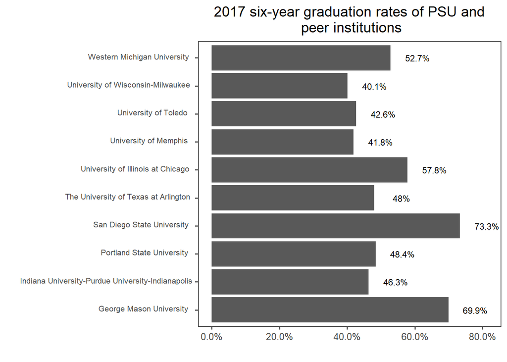

```r
 grad_rate %>%
  filter(unitid %in% the_colleges) %>%
  filter(year == 2017)%>%
  arrange((getinstnm[as.character(unitid)])) %>%
  ggplot(aes((getinstnm[as.character(unitid)]), rate)) +
  geom_bar(stat="identity") +
    theme_few() +
  theme(legend.position="none") +
  scale_y_continuous(labels = scales::percent) +
  geom_text(aes(label=paste0(round(rate*100,1),"%"), y=rate+0.08), size=3) +
  coord_flip() +
  ylab('') +
  xlab('') +
  theme(axis.text.y=element_text(size=8, hjust=0.95,vjust=0.2)) +
  ggtitle('2017 six-year graduation rates of PSU and\n peer institutions') +
  theme(plot.title = element_text(hjust = 0.5))
```